# results

Vera Kvisgaard

2024-08-20

This note shows results from simulation experiments on BIDA with local structure. Both in the structure learning part of the BIDA procedure and in the local-backdoor-estimation step, a partition of the relevant CPTs are learned in a greedy structure: fitting either a tree-structure or a decision graph / labeled graph.

## Parameter explantion

The different simulation settings are characterized by the following parameters: - `network`: - `init`: algorithm for learning the initial search space for the MCMC chain. Either`bnlearn::hc` or `pcalg::pc` is used to learn an CPDAG, and `*skel` means that the undirected skeleton is used. The initial seach space is iteratively expanded with the `BiDAG:::IterativeMCMC` procedure. - `struct`: Algorithm for optimizing the local CPTs. `none`for standard, full CPTs. `tree` or `ldag`. - `sample`: MCMC scheme used to sample dags. `order` - `ess`: equivalent sample size. Sat equal to 1. Defaults to .5 in BiDAG. - `epf`: edge penalty. An penalty term `log(epf)*length(parentnodes)` is added to the score for each node. Defaults to 2 in BiDAG. - `regular`: if `TRUE`, the partitioing over parent-outcomes is forced to be regular. I.e. to not encode any conditional independencies. Required for maximal-ldag-consistency.

```r
library(ggplot2)
here::i_am("inst/simulations/ldags/results.rmd")
```

```
## here() starts at C:/Users/verak/OneDrive - Universitetet i Oslo/Documents/git/personal/bida
```

```r
indir <- here::here("inst/simulations/ldags/results/")
```

```r
# extract params from filenames
params_from_filenames <- function(files,
                                  names = c("network", "init", "struct", "sample", "ess", "epf", "regular", "N", "r")) {
  tmp <- stringr::str_split(gsub("^(.*[\\/])|.rds", "", files), "_", simplify = FALSE)
  df <- data.frame(do.call(rbind, tmp), stringsAsFactors = F)
  names(df) <- names

  df$N <- factor(as.numeric(gsub("N", "", df$N)))

  levels <- unique(df$epf)
  levels <- levels[order(as.numeric(gsub("epf", "",  levels)))]
  df$epf <- factor(df$epf, levels)

  levels <- c("none", "tree", "ldag")
  df$struct <- factor(df$struct, levels)

  df$structr <- interaction(df$struct, df$regular)

  df

}

# prettify ggplots
prettify_plot <- function(plot) {
  list(theme_minimal(),
       theme(legend.position = "bottom"))
}

# plot box plot with ggplot
plot_boxplot <- function(df, x = "N", y, fill = "structr",
                         facets = as.formula("init+sample+ess~network+epf")) {
  ggplot(df, aes(!! sym(x), !! sym(y), fill = !! sym(fill))) +
  facet_grid(facets) +
  geom_boxplot() +
  prettify_plot()
}
```

### Counts of each simulation setting

For each simulation setting, up to 30 simulation runs. When the table below shows a lower frequency for some settings, the simulation is not complete. At each run, the different structure learning procedures are applied to a single data set sampled from the network.

```r
files <- list.files(indir, ".rds", full.names = TRUE)
df_par <- params_from_filenames(files)
include <- !names(df_par) %in% c("r", "structr")
data.frame(table(df_par[, include]))
```

```
##    network   init struct sample  ess   epf regular     N Freq
## 1     asia     hc   none  order ess1  epf2    reg1   100   13
## 2     asia hcskel   none  order ess1  epf2    reg1   100   13
## 3     asia     hc   tree  order ess1  epf2    reg1   100   13
## 4     asia hcskel   tree  order ess1  epf2    reg1   100   13
## 5     asia     hc   ldag  order ess1  epf2    reg1   100   13
## 6     asia hcskel   ldag  order ess1  epf2    reg1   100   13
## 7     asia     hc   none  order ess1  epf4    reg1   100    0
## 8     asia hcskel   none  order ess1  epf4    reg1   100    0
## 9     asia     hc   tree  order ess1  epf4    reg1   100   13
## 10    asia hcskel   tree  order ess1  epf4    reg1   100   13
## 11    asia     hc   ldag  order ess1  epf4    reg1   100   13
## 12    asia hcskel   ldag  order ess1  epf4    reg1   100   13
## 13    asia     hc   none  order ess1 epf16    reg1   100    0
## 14    asia hcskel   none  order ess1 epf16    reg1   100    0
```

[output cut: 76 more lines]

# Asia, 8 nodes

The Asia network is the smallest and easiest to run with a wide range of different simulation settings, shown in the following.

```r
# import simulation results
files <- list.files(indir, pattern = "asia.*.rds", full.names = T)
imp <- lapply(files, readRDS)
tmp <- lapply(imp, "[[", "res")
len <- lengths(tmp)
stopifnot(all(len == len[1]))

# store in data frame
df <- cbind(params_from_filenames(files), do.call(rbind, tmp))
```

## True and false positive rate

The true and false positive rate of the edges (TPR and FPR, respectively), averaged over all DAGs in the sample. The higher FPR when learning DAGs with local structure suggests spurious edges. Mitigated by increasing the edge penalty parameter `epf`.

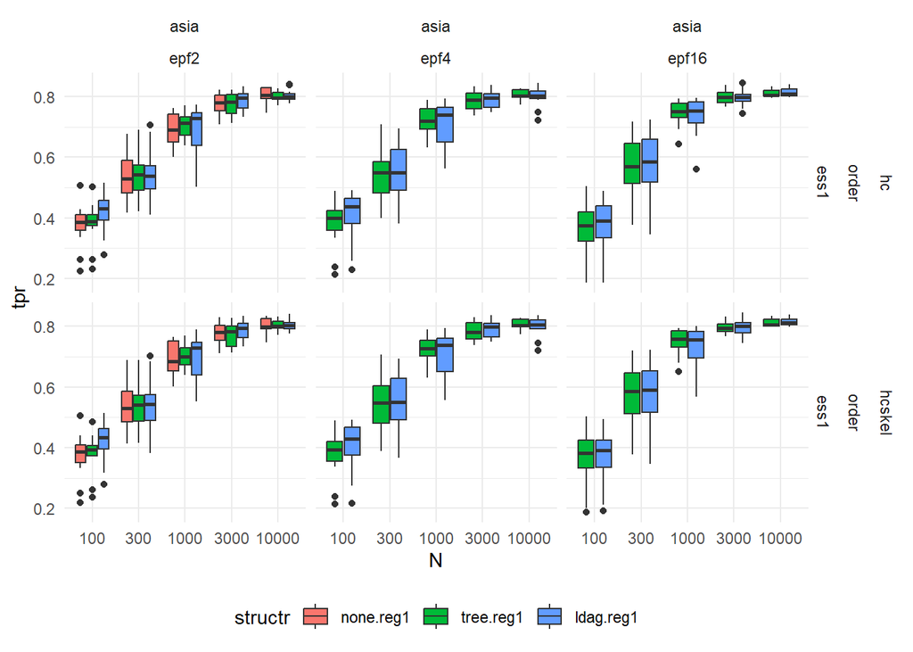

```r
plot_boxplot(df, "N", "tpr")
```

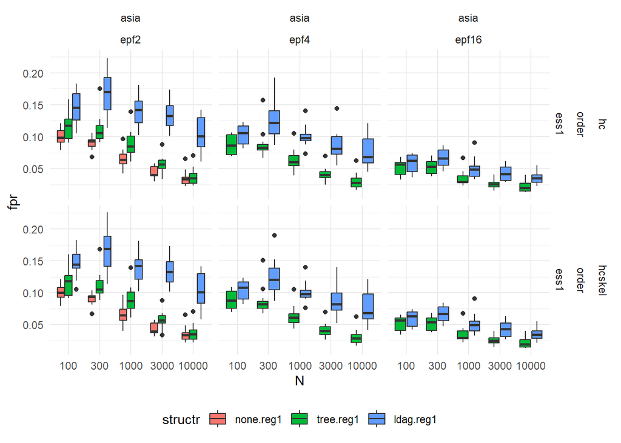

```r
plot_boxplot(df, "N", "fpr")
```

## Precision-recall

The area under the precision recall curve, approximated by the average precision (`avgppv`). Based on the posterior edge probabilities (`edgep`) and the posterior ancestor relation probabilities (`arp`).

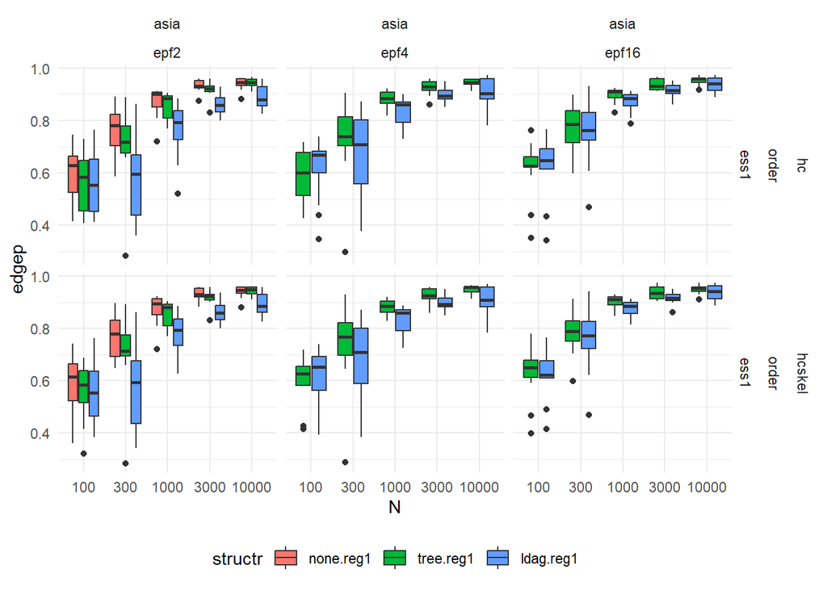

```r
plot_boxplot(df, "N", "edgep")
```

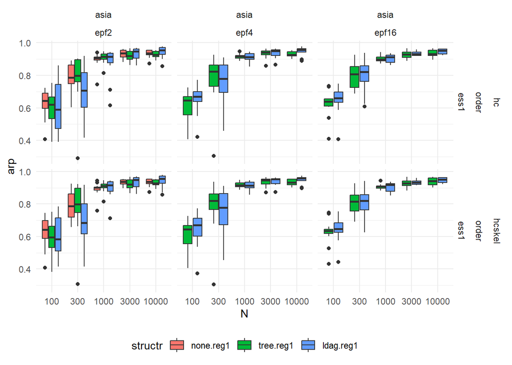

```r
plot_boxplot(df, "N", "arp")
```

## Intervention distribution

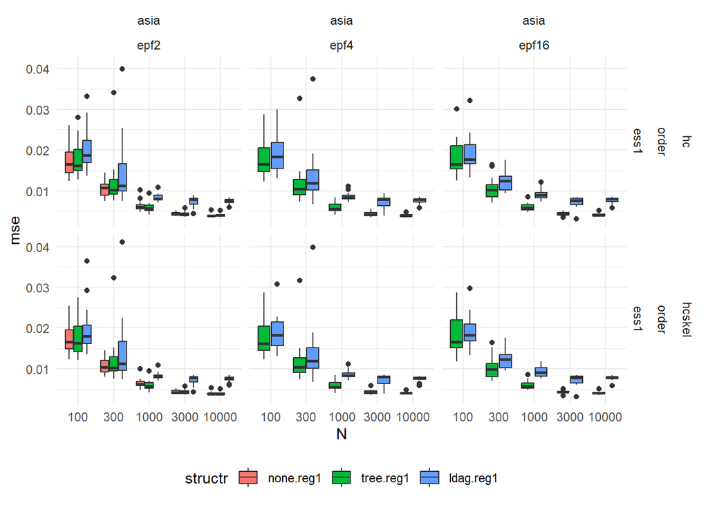

```r
plot_boxplot(df, "N", "mse")
```

# Larger networks

```r
files <- list.files(indir, pattern = ".rds", full.names = T)
files <- files[!grepl("asia", files)]

if (length(files) > 0) {
  imp <- lapply(files, readRDS)
  df <- cbind(params_from_filenames(files), do.call(rbind, tmp))

  # true positive edge rate
  plot_boxplot(df, "N", "tpr")

  # false positive edge rate
  plot_boxplot(df, "N", "fpr")

  # average precision, edges
  plot_boxplot(df, "N", "edgep")

  # average precision, arp
  plot_boxplot(df, "N", "arp")

  # mse of intervention probs
  plot_boxplot(df, "N", "mse")
}
```